# STA 533 Homework 5

Melanie Miller

West Chester University

# 1 Introduction

In this analysis, data sets “income per person”, “life expectancy”, “countries total”, and “population total” were used. Together, these data sets make up information that has a potential impact on the life expectancy of the world. The following analysis merges these data sets together, keeping critical variables like country, year, income, life expectancy, region, and population size. With the combined data, a scatter plot was created to look at the trends surrounding these important variables in the year 2000.

# 2 Data Preparation

Importing the data:

```r
inc.per.person<-read.csv(url("https://melaniemiller1.github.io/STA533/w05-HW/income_per_person.csv"))
life.expect<-read.csv(url("https://melaniemiller1.github.io/STA533/w05-HW/life_expectancy_years.csv"))
countries.tot<- read.csv(url("https://melaniemiller1.github.io/STA533/w05-HW/countries_total.csv"))
population.tot<- read.csv(url("https://melaniemiller1.github.io/STA533/w05-HW/population_total.csv"))
```

Reshaping the “income per person” data set to be longitudinal with 3 variables: country, year, and income, and it has 42,267 observations.

```r
#Income per person data prep

inc.per.person2 <- inc.per.person %>%
  gather(key = "year", value = "Income", - geo, na.rm = TRUE)

inc.per.person2 <- inc.per.person2 %>%
                      mutate(Year = substr(year,2,5)) %>%
                      select(-year)

inc.per.person2 <- inc.per.person2 %>%
  rename("Country" = "geo")
```

Reshaping the “life expectancy” data set to be longitudinal with 3 variables: country, year and life expectancy, and it has 40,437 observations.

```r
#Life expectancy data prep

life.expect2 <- life.expect %>%
  gather(key = "year", value = "Expectancy", - geo, na.rm = TRUE)

life.expect2 <- life.expect2 %>%
                      mutate(Year = substr(year,2,5)) %>%
                      select(-year)

life.expect2 <- life.expect2 %>%
  rename("Country" = "geo")
```

Merging the longitudinal versions of income per person and life expectancy to become a new data set called “LifeExpIncome” that has the 4 variables: country, year, life expectancy, and income, which has 42,267 observations.

```r
#Merge income per person and life expectancy by country and year

LifeExpIncome <- merge(inc.per.person2, life.expect2 ,by=c("Country","Year"), all=TRUE)
```

Merging the new LifeExpIncome with the countries total data set, while also removing all the additional variables that are not needed, so we add information on the region to the values already in LifeExpIncome. A left join merging method was used to keep all the country values of LifeExpIncome and add the regions in addition to these values without adding any new country values.This new data set has 5 variables: Country, Year, Income, Expectancy, and region and 42,267 observations.

```r
#Prep countries total data
countries.tot <- countries.tot %>%
  rename("Country" = "name")

#Removing variables not needed
countries.tot <- countries.tot%>%
                      select(-alpha.2, -alpha.3, -country.code, -iso_3166.2, -sub.region, -intermediate.region, -region.code,
                             -sub.region.code, -intermediate.region.code)

#Merge LifeExpIncome and country region
LifeExpInc<-merge(LifeExpIncome, countries.tot, by = "Country", all.x = TRUE)

#LifeExpIncome2 <- merge(LifeExpIncome, countries.tot$region)
```

Reshaping the “population total” data set to be longitudinal with 3 variables: country, year, and population size.This data set has 3 avriables: Country, Population, and Year, and has 42,705 observations.

```r
#Population total data prep

pop.total <- population.tot %>%
  gather(key = "year", value = "Population", - geo, na.rm = TRUE)

pop.total <- pop.total %>%
                      mutate(Year = substr(year,2,5)) %>%
                      select(-year)

pop.total <- pop.total %>%
  rename("Country" = "geo")
```

Merging LifeExpInc data set with population total by Country and Year so the final data set includes the following 6 variables: Country, Year, Income, Life Expectancy, and Population size, and ahs 42,705 observations. The final data was also exported.

```r
final.data <- merge(LifeExpInc, pop.total ,by=c("Country","Year"), all = TRUE)

write_csv(final.data, file = "C:/Users/mille/Documents/WCU Grad School 2022-2024/WCU Grad Spring 2024/STA 533 Data Visualization/STA533/w05-HW/final_data.csv")
```

# 3 Summarizing the Data

In the final data set there are 42,705 observations and 6 variables: Country, Year, Income, Expectancy, Region, and Population.

Creating a subset of the above final longitudinal data set that contains only the data of the year 2000. This data set has the same 6 variables and has 195 observations.

```r
data2000<- final.data %>%
             filter(Year == 2000)
```

# 4 Scatter Plot of the Association of Life Expectancy and Income

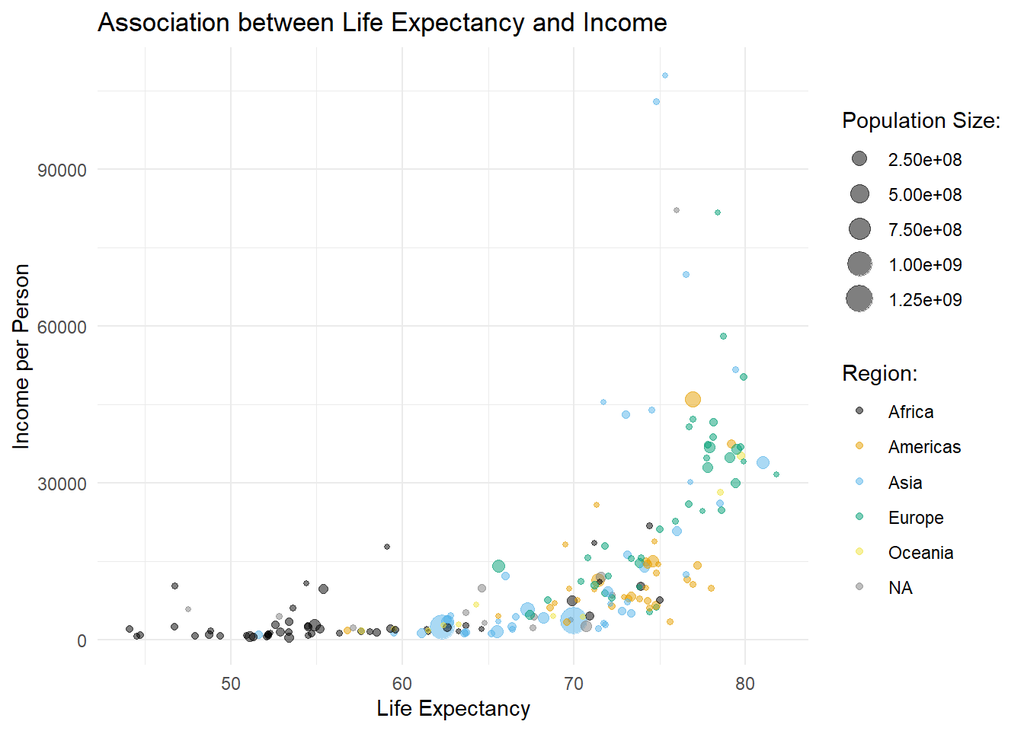

```r
cols1 = c("#000000","#E69F00","#56B4E9","#009E73","#F0E442","#0072B2")

ggplot(data2000, aes(x = Expectancy, y = Income,
                              color = region,
                              size = Population)) +
             geom_point(alpha = 0.5) + scale_color_manual(values = cols1) +
             labs(x = "Life Expectancy",
                 y = "Income per Person",
                 # label for legends
                 size = "Population Size:",
                 color = "Region:",
                 title = "Association between Life Expectancy and Income") +
             theme_minimal()
```

This plot is a scatter plot that shows the relationship between life expectancy and income per person. The size of the points reflects the population size, the larger the point that larger the population size, and the colors are reflective of the region. From this plot, it is clear that those with longer life expectancy have higher income, and those with low life expectancy have low income. There does not appear to be any trends for population size, each category appears to be spread out. However, it may be worth noting the largest population sizes are in located in the middle life expectancy, mostly between 60 and 70 years. In terms of region, it appears Africa has a trend of having lower life expectancy and income as displayed by the clusters seen. There is also a cluster of Asia in the middle range, between 60 and 70 years, of life expectancy, as well as a cluster of the Americas around 75 years. Europe appears to have the most clear cluster in the higher end of life expectancy and income, close to 80 years.

```r
#Completed, merged data set
completed_data<-read.csv(url("https://melaniemiller1.github.io/STA533/w05-HW/final_data.csv"))
```